# Model Altmana

Metody ryzyka kredytowego i operacyjnego (2026)

Aleksandra Konopelska

2026-05-18

# 1 Część teoretyczna

## 1.1 Odpowiedzieć na pytanie, czym jest ryzyko kredytowe?

Najprościej mówiąc, ryzyko kredytowe to ryzyko, że ktoś, komu pożyczyliśmy pieniądze, nie wywiąże się ze swoich zobowiązań, czyli nie spłaci długu w umówionym terminie, nie zapłaci odsetek albo zwróci tylko część należnej kwoty. Pojawia się wszędzie tam, gdzie jedna strona oddaje drugiej kapitał i liczy na jego spłatę np. gdy bank udziela firmie kredytu albo gdy inwestor kupuje obligacje wyemitowane przez jakąś spółkę.

Ryzyko kredytowe można rozumieć dwojako:

- jako **ryzyko niedotrzymania warunków (default risk)**: czyli bezpośrednie ryzyko, że dłużnik nie wywiąże się ze swoich zobowiązań umownych,
- jako **ryzyko wiarygodności kredytowej (creditworthiness risk)**: czyli ryzyko, że sytuacja finansowa klienta się pogorszy i jego zdolność do obsługi długu spadnie, jeszcze zanim faktycznie zaprzestanie spłat.

Można na nie patrzeć też z dwóch poziomów:

- z poziomu **pojedynczego/indywidualnego klienta** i wtedy mówimy o *credit scoringu*, czyli o ocenie konkretnej osoby lub firmy.
- z poziomu **całego portfela kredytów** banku, czyli wszystkich udzielonych pożyczek i kredytów łącznie. Tutaj pytamy nie o jednego klienta, ale o to, ile bank może stracić, gdy wielu klientów naraz nie spłaci swoich zobowiązań. Do tego służą np. modele takie jak *CreditMetrics*.

Żeby to ryzyko zmierzyć ilościowo, w praktyce szacuje się trzy podstawowe wielkości:

- **PD** (*probability of default*), czyli z jakim prawdopodobieństwem klient nie spłaci długu,
- **LGD** (*loss given default*), czyli ile bank traci, gdy klient przestaje spłacać. Jeśli klient pożyczył 100 zł i bankrutuje, a bankowi udaje się odzyskać część przez sprzedaż jego majątku, to ta nieodzyskana reszta to LGD. Szacuje się ją na podstawie historycznych danych o tym, ile w przeszłości udawało się odzyskać od bankrutów,
- **korelacje niedotrzymania**, czyli czy firmy bankrutują niezależnie od siebie, czy razem. W praktyce bankructwa często się „grupują”, np. w czasie kryzysu lub pandemii wiele firm z tej samej branży upada naraz. To sprawia, że ryzyko całego portfela może być znacznie wyższe, niż gdybyśmy patrzyli na każdego klienta osobno.

Ryzyko kredytowe od dawna jest jednym z głównych obszarów modelowanych przez banki. Już od lat 60. XX wieku powstają coraz nowsze modele, które pomagają je przewidywać i kontrolować. Wyróżnia się trzy główne typy modeli ryzyka kredytowego: **strukturalne**, **empiryczne** (do których należy właśnie model Altmana) oraz **zredukowane**. Osobną klasę stanowią modele **scoringowe** i **ratingowe**.

## 1.2 Zwięźle omówić ideę liniowej analizy dyskryminacyjnej. Dlaczego można ją wykorzystać do analizy ryzyka kredytowego?

Liniowa analiza dyskryminacyjna to narzędzie ilościowe wykorzystywane do budowania modeli prognozowania upadłości firm. Jej idea to: zamiast oceniać firmę na podstawie jednego wskaźnika finansowego, bierze pod uwagę wiele wskaźników jednocześnie i na ich podstawie dzieli firmy na rozłączne grupy różniące się poziomem ryzyka upadłości, np. „brak ryzyka”, „małe ryzyko” lub „wysokie ryzyko”.

Można ją wykorzystać do analizy ryzyka kredytowego, ponieważ ryzyko kredytowe to w praktyce ryzyko, że firma nie spłaci długu, czyli najczęściej, że upadnie. LDA pozwala bankowi na podstawie sprawozdań finansowych firmy ocenić, do której grupy firma należy: tych zagrożonych upadłością czy tych bezpiecznych. Dzięki temu bank może z wyprzedzeniem podjąć decyzję, czy udzielić kredytu, czy nie. Właśnie na tej metodzie opiera się model Altmana.

## 1.3 Jaką ma postać, do czego służy i jakie ograniczenia ma model Altmana?

**Postać modelu.** Model Altmana jest liniową funkcją dyskryminacyjną opartą na pięciu wskaźnikach finansowych. Został zbudowany na próbie 66 amerykańskich firm działających w latach 1946–1965, podzielonych na dwie równe grupy: bankrutów i firm prowadzących normalną działalność. Spośród 22 wstępnie rozważanych wskaźników finansowych Altman ostatecznie wybrał pięć:

- $X_1$ — **kapitał obrotowy / aktywa ogółem**, pokazuje ile firma ma “wolnych” pieniędzy na bieżącą działalność (po opłaceniu krótkoterminowych długów) w stosunku do całego majątku. Mierzy **płynność**, czyli to, czy firma ma z czego płacić bieżące rachunki.
- $X_2$ — **zysk zatrzymany / aktywa ogółem**, czyli ile firma uzbierała zysków przez lata działalności. Pokazuje **skumulowaną rentowność**, a pośrednio również wiek firmy (młode firmy mają tu niskie wartości, bo nie zdążyły jeszcze nic odłożyć).
- $X_3$ — **EBIT / aktywa ogółem** (zysk przed odsetkami i podatkiem), ile firma zarabia na swojej podstawowej działalności w stosunku do majątku. Mierzy **rentowność operacyjną**, czyli to, czy firma w ogóle zarabia na tym co robi.
- $X_4$ — **rynkowa wartość akcji / wartość długów**, porównuje to, ile inwestorzy są skłonni zapłacić za akcje firmy na giełdzie, z tym, ile firma jest winna. Jeśli akcje są warte więcej niż długi ($X_4 > 1$), to znak, że inwestorzy ufają firmie. Jeśli mniej, to znak, że firma jest poważnie zadłużona w stosunku do swojej wartości rynkowej.
- $X_5$ — **przychody ze sprzedaży / aktywa ogółem**, czyli ile firma sprzedaje w stosunku do tego, ile ma majątku. Mierzy **sprawność**, czyli to, jak efektywnie firma wykorzystuje swój majątek do zarabiania.

Końcowa postać funkcji dyskryminacyjnej Altmana:

$$Z = 1{,}2\,X_1 + 1{,}4\,X_2 + 3{,}3\,X_3 + 0{,}6\,X_4 + 0{,}99\,X_5$$

**Reguła klasyfikacji (interpretacja wyników modelu Altmana):**

- $Z > 3{,}0$ - bankructwo mało prawdopodobne (firma w dobrej kondycji),
- $1{,}8 < Z < 3{,}0$ - szara strefa (model nie wydaje jednoznacznego werdyktu),
- $Z < 1{,}8$ - bankructwo (firma zagrożona upadłością).

**Do czego służy.** Model Altmana jest zastosowaniem analizy dyskryminacyjnej do prognozowania upadłości przedsiębiorstw. Pozwala on na podstawie kilku wskaźników finansowych ocenić, czy dana firma będzie **wiarygodnym kredytobiorcą**, czy też grozi jej bankructwo. Z perspektywy banku jest to więc narzędzie typu *credit scoring*.

**Ograniczenia.** Za ograniczenia modelu Altmana uważa się, że:

- model jest **liniowy**, używa prostej formuły (mnożenia i dodawania) i zakłada, że im gorsze wskaźniki, tym gorzej dla firmy. W rzeczywistości upadek firmy często nie przebiega tak liniowo: czasem nagle coś się załamie, a czasem firma utrzymuje się długo mimo słabych wskaźników.
- model **operuje na danych księgowych**, bierze dane ze sprawozdań finansowych, które publikuje się np. raz na kwartał albo raz na rok. Czyli widzi sytuację firmy z opóźnieniem, a nie na bieżąco.
- model jest **prosty i bazuje na niewielkiej liczbie informacji**, używa tylko 5 wskaźników. Tymczasem o kondycji firmy może decydować dużo więcej rzeczy (zarząd, branża, otoczenie rynkowe, klienci itd.), których model nie uwzględnia.
- użycie zmiennej $X_4$ (wartość **rynkowa** kapitału akcyjnego) ogranicza zastosowanie oryginalnego modelu do **spółek notowanych na giełdzie**, ponieważ tylko dla nich da się policzyć rynkową wartość akcji. Dla firm prywatnych model w oryginalnej wersji nie zadziała.
- model ma **słabą przenośność między krajami**, został zbudowany na amerykańskich firmach z lat 60. W innym kraju (na przykład w Polsce) firmy mają inne standardy księgowe i działają w innej gospodarce, więc te same wskaźniki znaczą co innego. Firma uznana przez model za bezpieczną w USA, w Polsce mogłaby w rzeczywistości być zagrożona, i odwrotnie.

# 2 Część praktyczna

W tej części:

1. Wczytuję zbiór danych *Polish Companies Bankruptcy* (plik `5year`) zawierający wskaźniki finansowe polskich firm oraz informację o tym, czy firma upadła po roku.
2. Losuję próbę: 100 firm, które upadły, i 100, które przetrwały kolejny rok działalności.
3. Stosuję oryginalny model Altmana do predykcji upadłości na tej próbie i oceniam jakość tej predykcji (macierz pomyłek, błędy I i II rodzaju, trafność).
4. Odpowiadam na pytanie, czy oryginalny model Altmana jest skutecznym narzędziem do predykcji upadłości w przypadku tych danych, i staram się wyjaśnić, dlaczego tak jest.

## 2.1 Wczytanie danych

Pracuję na zbiorze *Polish Companies Bankruptcy* z UCI Machine Learning Repository, a dokładnie na pliku `5year`, który zawiera wskaźniki finansowe z 5. roku okresu prognozy oraz etykietę informującą o upadłości po 1 roku.

**Link do zbioru:** https://archive.ics.uci.edu/dataset/365/polish+companies+bankruptcy+data

Wczytuję plik CSV. Wartości brakujące są zakodowane jako `?`, więc przekazuję to do funkcji przez `na.strings`.

```r
# wczytanie danych z pliku CSV; "?" traktowane jako brak danych
dane <- read.csv("csv_result-5year.csv",
                 header      = TRUE,
                 na.strings  = "?",
                 stringsAsFactors = FALSE)
```

Sprawdzam ile wierszy (firm) i kolumn (zmiennych) ma zbiór:

```r
# liczba wierszy i kolumn
dim(dane)
```

```
## [1] 5910   66
```

Podgląd pierwszych kilku wierszy:

```r
# pierwsze 6 wierszy, pierwsze 10 kolumn
head(dane[, 1:10])
```

```
##   id     Attr1   Attr2   Attr3  Attr4    Attr5     Attr6     Attr7   Attr8
## 1  1  0.088238 0.55472 0.01134 1.0205 -66.5200  0.342040  0.109490 0.57752
## 2  2 -0.006202 0.48465 0.23298 1.5998   6.1825  0.000000 -0.006202 1.06340
## 3  3  0.130240 0.22142 0.57751 3.6082 120.0400  0.187640  0.162120 3.05900
## 4  4 -0.089951 0.88700 0.26927 1.5222 -55.9920 -0.073957 -0.089951 0.12740
## 5  5  0.048179 0.55041 0.10765 1.2437 -22.9590  0.000000  0.059280 0.81682
## 6  6  0.231560 0.51047 0.47291 1.9393  15.1020  0.000000  0.287690 0.95899
##    Attr9
## 1 1.0881
## 2 1.2757
## 3 1.1415
## 4 1.2754
## 5 1.5150
## 6 1.7915
```

Sprawdzam ile firm upadło (`class = 1`), a ile przetrwało (`class = 0`):

```r
# rozkład zmiennej celu: 0 = przetrwała, 1 = upadła
table(dane$class)
```

```
##
##    0    1
## 5500  410
```

Obliczam jaki procent wszystkich firm stanowią bankruci:

```r
# procent bankrutów w całym zbiorze
round(mean(dane$class == 1) * 100, 1)
```

```
## [1] 6.9
```

Zbiór zawiera 5910 firm i 66 zmiennych. Etykieta `class = 1` oznacza firmę, która upadła po 1 roku, a `class = 0` firmę, która przetrwała. W zbiorze jest 410 bankrutów i 5500 firm, które przetrwały. Zbiór jest mocno niezrównoważony: bankruci stanowią zaledwie 6,9% obserwacji. Dlatego zadanie wymaga dokładnie 100 + 100, aby obie grupy (bankruci i firmy, które przetrwały) były równomiernie reprezentowane w próbie. Gdybym losowała 200 firm z całego zbioru proporcjonalnie, dostałabym zaledwie ok ~14 bankrutów, a model nauczyłby się głównie rozpoznawać firmy, które przetrwały.

## 2.2 Wybór zmiennych do modelu Altmana

Zbiór danych z UCI Machine Learning Repository zawiera opis, które kolumny (Attr1, Attr2 itd.) odpowiadają którym wskaźnikom finansowym. Zgodnie z tym opisem oraz treścią zadania pięć wskaźników modelu Altmana odpowiada następującym kolumnom z pliku:

| Zmienna Altmana | Definicja | Kolumna w pliku |
| --- | --- | --- |
| X1 | Working capital / Total assets | `Attr3` |
| X2 | Retained earnings / Total assets | `Attr6` |
| X3 | EBIT / Total assets | `Attr7` |
| X4 | (Book) equity / Book value of total liabilities | `Attr8` |
| X5 | Sales / Total assets | `Attr9` |

**Uwaga do zmiennej $X_4$,** w oryginalnym modelu Altmana $X_4$ to rynkowa wartość kapitału własnego (czyli wartość akcji na giełdzie) podzielona przez zobowiązania. W zbiorze UCI mamy jednak tylko wartość księgową (kolumna Attr8 = book value of equity / total liabilities). Używam więc wartości księgowej zamiast rynkowej, wracam do tej różnicy we wnioskach.

Wybieram z oryginalnego zbioru tylko te 5 kolumn i kolumnę `class`, a następnie usuwam wiersze z brakującymi wartościami:

```r
# tworzę ramkę danych z 5 wskaźnikami Altmana i etykietą klasy
df <- data.frame(
  X1     = dane$Attr3,   # kapitał obrotowy / aktywa
  X2     = dane$Attr6,   # zysk zatrzymany / aktywa
  X3     = dane$Attr7,   # EBIT / aktywa
  X4     = dane$Attr8,   # kapitał własny / zobowiązania
  X5     = dane$Attr9,   # sprzedaż / aktywa
  status = dane$class    # etykieta: 1 = bankrut, 0 = przetrwał
)

# usuwam wiersze, w których brakuje wartości w którymkolwiek wskaźniku
df <- df[complete.cases(df), ]
```

Sprawdzam ile firm zostało po usunięciu braków danych:

```r
# liczba firm po usunięciu braków: 0 = przetrwały, 1 = upadły
table(df$status)
```

```
##
##    0    1
## 5485  406
```

Po usunięciu braków danych zostało 5485 firm, które przetrwały, i 406 bankrutów.

## 2.3 Losowanie próby 100 + 100

Dzielę zbiór na dwie grupy: bankruci i firmy, które przetrwały. Następnie losuję po 100 firm z każdej grupy.

```r
set.seed(2026)  # ustawiam ziarno losowości dla powtarzalności wyników

bankruci <- df[df$status == 1, ]   # wybieram tylko bankrutów
przetrwale <- df[df$status == 0, ]   # wybieram tylko firmy, które przetrwały

prob_bank <- bankruci[sample(nrow(bankruci), 100), ]   # losuję 100 bankrutów
prob_zdr  <- przetrwale[sample(nrow(przetrwale), 100), ]   # losuję 100 firm, które przetrwały

proba <- rbind(prob_bank, prob_zdr)        # łączę obie grupy w jedną próbę
proba <- proba[sample(nrow(proba)), ]      # mieszam kolejność wierszy
```

Sprawdzam czy w próbie są dokładnie po 100 firm z każdej grupy:

```r
table(proba$status)
```

```
##
##   0   1
## 100 100
```

W próbie jest dokładnie 100 bankrutów (`status = 1`) i 100 firm, które przetrwały (`status = 0`).

## 2.4 Funkcja licząca Z-score Altmana

Funkcja `altman_z()` zwraca wartość $Z$ wyliczoną zgodnie z wzorem:

$$Z = 1{,}2\,X_1 + 1{,}4\,X_2 + 3{,}3\,X_3 + 0{,}6\,X_4 + 0{,}99\,X_5$$

Funkcja `altman_klasyfikacja()` przypisuje firmę do jednej z trzech stref (progi **1,8** i **3,0**):

- $Z < 1{,}8$ → bankrut (`1`),
- $Z > 3{,}0$ → firma, która przetrwa (`0`),
- $1{,}8 \le Z \le 3{,}0$ → szara strefa (`NA`, brak jednoznacznej decyzji).

```r
# funkcja obliczająca z-score wg wzoru Altmana
altman_z <- function(X1, X2, X3, X4, X5) {
  1.2*X1 + 1.4*X2 + 3.3*X3 + 0.6*X4 + 0.99*X5
}

# funkcja klasyfikująca firmę na podstawie z-score
altman_klasyfikacja <- function(Z) {
  klasa <- rep(NA_integer_, length(Z))  # na start wszystkie = NA (szara strefa)
  klasa[Z < 1.8] <- 1   # Z poniżej 1.8 -> bankrut
  klasa[Z > 3.0] <- 0   # Z powyżej 3.0 -> firma, która przetrwa
  # Z między 1.8 a 3.0 pozostaje NA (szara strefa -> brak decyzji)
  klasa
}
```

## 2.5 Predykcja upadłości na próbie

Dla każdej firmy z próby obliczam Z-score i przypisuję klasę:

```r
# obliczam Z-score dla każdej firmy w próbie
proba$Z    <- with(proba, altman_z(X1, X2, X3, X4, X5))

# klasyfikuję każdą firmę (bankrut / przetrwa / szara strefa)
proba$pred <- altman_klasyfikacja(proba$Z)
```

Statystyki opisowe wartości Z-score w próbie:

```r
# min, max, mediana i inne statystyki rozkładu Z-score
summary(proba$Z)
```

```
##     Min.  1st Qu.   Median     Mean  3rd Qu.     Max.
## -237.412    1.190    2.457    1.456    4.090   16.470
```

Wartości Z-score w próbie są bardzo zróżnicowane, od -237,4 do 16,5. Mediana wynosi 2,457, co oznacza, że połowa firm ma Z-score w okolicach szarej strefy (1,8–3,0). Średnia (1,456) jest niższa od mediany przez kilka bardzo ujemnych wartości skrajnych.

### 2.5.1 Macierz pomyłek (3 strefy)

Buduję macierz pomyłek porównującą rzeczywisty status firmy z predykcją modelu. Kolumna `<NA>` to firmy w szarej strefie, dla których model nie wydał decyzji:

```r
# macierz pomyłek: wiersze = rzeczywistość, kolumny = predykcja modelu
tab <- table(rzeczywiste = proba$status,
             predykcja   = proba$pred,
             useNA       = "ifany")
tab
```

```
##            predykcja
## rzeczywiste  0  1 <NA>
##           0 60 22   18
##           1 23 57   20
```

Z macierzy wynika:

- **60** firm, które przetrwały, zostało poprawnie sklasyfikowanych jako niebankruci,
- **22** firmy, które przetrwały, zostały błędnie uznane za bankrutów (błąd II rodzaju),
- **18** firm, które przetrwały, wpadło w szarą strefę = brak decyzji,
- **57** bankrutów zostało poprawnie wykrytych,
- **23** bankrutów zostało błędnie sklasyfikowanych jako firmy, które przetrwają (błąd I rodzaju),
- **20** bankrutów wpadło w szarą strefę = brak decyzji.

Obliczam trafność tylko na firmach, które model zdołał sklasyfikować (czyli poza szarą strefą):

```r
sklasyfikowane <- proba[!is.na(proba$pred), ]
n_skl  <- nrow(sklasyfikowane)         # ile firm zostało sklasyfikowanych
n_szar <- sum(is.na(proba$pred))       # ile wpadło w szarą strefę
acc    <- mean(sklasyfikowane$pred == sklasyfikowane$status)  # trafność
```

Zestawienie wyników:

```r
# tabela z podsumowaniem: ile sklasyfikowano, ile w szarej strefie, jaka trafność
data.frame(
  opis    = c("Sklasyfikowane firmy (z 200)",
              "Firmy w szarej strefie (z 200)",
              "Trafność (na sklasyfikowanych)"),
  wartość = c(n_skl, n_szar, round(acc, 3))
)
```

```
##                             opis wartość
## 1   Sklasyfikowane firmy (z 200) 162.000
## 2 Firmy w szarej strefie (z 200)  38.000
## 3 Trafność (na sklasyfikowanych)   0.722
```

Model sklasyfikował **162 z 200 firm**. Pozostałe **38 firm** wpadło w szarą strefę i nie otrzymało żadnej decyzji. Na 162 sklasyfikowanych firmach model osiągnął trafność **72,2%**.

### 2.5.2 Błędy I i II rodzaju

W kontekście oceny ryzyka kredytowego najgroźniejszy jest **błąd I rodzaju**, czyli uznanie bankruta za zdrową firmę (bank udziela kredytu firmie, która zaraz upadnie). Liczymy go na firmach, dla których model wydał decyzję.

Obliczam elementy macierzy pomyłek i na ich podstawie liczę miary jakości:

```r
sk <- sklasyfikowane  # skrót dla wygody :)

# elementy macierzy pomyłek
TP <- sum(sk$pred == 1 & sk$status == 1)  # bankrut poprawnie wykryty
TN <- sum(sk$pred == 0 & sk$status == 0)  # firma, która przetrwała -> poprawnie oceniona
FP <- sum(sk$pred == 1 & sk$status == 0)  # firma, która przetrwała -> uznana za bankruta (błąd II)
FN <- sum(sk$pred == 0 & sk$status == 1)  # bankrut uznany za firmę która przetrwa (błąd I)

# miary jakości klasyfikacji
sensitivity <- TP / (TP + FN)   # czułość: jak dobrze wykrywa bankrutów
specificity <- TN / (TN + FP)   # specyficzność: jak dobrze wykrywa firmy, które przetrwają
err_I       <- FN / (TP + FN)   # błąd I rodzaju: bankrut uznany za firmę, która przetrwa
err_II      <- FP / (TN + FP)   # błąd II rodzaju: firma, która przetrwała - uznana za bankruta

data.frame(
  miara   = c("Czułość (sensitivity)",
              "Specyficzność (specificity)",
              "Błąd I rodzaju (FN/(TP+FN))",
              "Błąd II rodzaju (FP/(TN+FP))",
              "Accuracy (na sklasyfikowanych)"),
  wartość = round(c(sensitivity, specificity, err_I, err_II, acc), 3)
)
```

```
##                            miara wartość
## 1          Czułość (sensitivity)   0.713
## 2    Specyficzność (specificity)   0.732
## 3    Błąd I rodzaju (FN/(TP+FN))   0.288
## 4   Błąd II rodzaju (FP/(TN+FP))   0.268
## 5 Accuracy (na sklasyfikowanych)   0.722
```

Model poprawnie wykrył **71,3%** bankrutów i **73,2%** firm, które przetrwały. Błąd I rodzaju wynosi **28,8%**, czyli co trzeci bankrut został błędnie uznany za firmę, która przetrwa. To najgroźniejszy błąd z punktu widzenia banku. Ogólna trafność na sklasyfikowanych firmach wynosi **72,2%**.

### 2.5.3 Wizualizacja rozkładu Z-score

Wykres pudełkowy pokazuje jak różnią się wartości Z-score między grupami. Czerwona linia to dolny próg 1,8, zielona to górny próg 3,0:

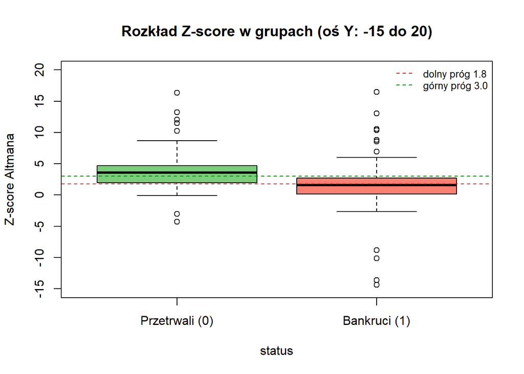

```r
# wykres pudełkowy Z-score w podziale na bankrutów i firmy, które przetrwały
# ylim ogranicza oś Y do zakresu -15 do 20, żeby ekstremalny outlier (-237)
# nie psuł skali wykresu
boxplot(Z ~ status, data = proba,
        names = c("Przetrwali (0)", "Bankruci (1)"),
        ylab  = "Z-score Altmana",
        main  = "Rozkład Z-score w grupach (oś Y: -15 do 20)",
        col   = c("palegreen3", "salmon"),
        ylim  = c(-15, 20))
abline(h = 1.8, col = "red",    lty = 2)   # dolny próg
abline(h = 3.0, col = "green4", lty = 2)   # górny próg
legend("topright",
       legend = c("dolny próg 1.8", "górny próg 3.0"),
       col    = c("red", "green4"),
       lty    = c(2, 2),
       bty    = "n",
       cex    = 0.8)
```

Z wykresu widać, że:

- **Firmy, które przetrwały** mają wyższe wartości Z-score. Mediana leży w okolicy progu 3,0, a większa część pudełka znajduje się powyżej progu 1,8, czyli w bezpiecznej strefie.
- **Bankruci** mają wyraźnie niższe wartości Z-score. Mediana jest poniżej progu 1,8, czyli w strefie bankructwa, a pudełko w większości leży pod dolnym progiem.
- **Oba “pudełka” częściowo nakładają się na szarą strefę** (pomiędzy liniami 1,8 a 3,0), co oznacza, że model nie ma jak jednoznacznie rozróżnić części firm z obu grup. To właśnie te firmy trafiają do szarej strefy.
- **Widać też outliery w obu grupach**, niektórzy bankruci mają bardzo wysokie Z-score (powyżej 10), a niektóre firmy, które przetrwały, mają ujemne wartości. To pokazuje, że model nie jest idealny i niektóre firmy wymykają się prostej klasyfikacji.

## 2.6 (Dodatkowo) Czy LDA poradziłaby sobie lepiej?

Model Altmana używa gotowych wag (1,2; 1,4; 3,3; 0,6; 0,99) wyestymowanych na amerykańskich firmach z 1968 roku. Sprawdzam, czy dopasowanie własnych wag do polskich danych da lepszą trafność niż te gotowe wagi. To sprawdza funkcja `lda()` z biblioteki `MASS`:

1. Bierze te same 5 wskaźników ($X_1, \dots, X_5$) co Altman,
2. Ale zamiast używać gotowych wag, sama wylicza własne współczynniki liniowe, które najlepiej rozdzielają bankrutów od firm, które przetrwały, na naszej próbie 200 polskich firm,
3. Następnie predykuje klasę każdej firmy (bankrut / nie-bankrut), tutaj nie ma szarej strefy, LDA daje zawsze jednoznaczną odpowiedź.

Jeśli LDA wyjdzie **lepsza** od oryginalnego Altmana, to potwierdzi, że wagi Altmana są słabo dopasowane do polskich danych. Jeśli wyjdzie **gorsza** coś innego jest przyczyną niskiej trafności modelu.

Dopasowuję model LDA na próbie 200 polskich firm:

```r
library(MASS)  # biblioteka z funkcją lda()

# uczę model LDA na naszej próbie (te same zmienne co Altman)
model_lda <- lda(status ~ X1 + X2 + X3 + X4 + X5, data = proba)
```

Wyniki modelu LDA, współczynniki i średnie grup:

```r
# wyświetlam dopasowany model: średnie grup i współczynniki dyskryminacyjne
model_lda
```

```
## Call:
## lda(status ~ X1 + X2 + X3 + X4 + X5, data = proba)
##
## Prior probabilities of groups:
##   0   1
## 0.5 0.5
##
## Group means:
##           X1          X2          X3       X4       X5
## 0  0.2637254  0.04607675  0.09399866 3.032346 1.378233
## 1 -0.9464550 -0.72727469 -0.47416504 1.384274 1.945109
##
## Coefficients of linear discriminants:
##           LD1
## X1  0.4666585
## X2 -0.6455478
## X3 -0.5467616
## X4 -0.1515271
## X5  0.2918489
```

Prawdopodobieństwa obu klas wynoszą 0,5, bo próba jest zrównoważona (100 bankrutów i 100 firm, które przetrwały). Średnie grup pokazują wyraźne różnice między bankrutami a firmami, które przetrwały, bankruci mają ujemne wartości X1, X2, X3, podczas gdy firmy, które przetrwały, mają wartości dodatnie. Współczynniki dyskryminacyjne LD1 to właśnie własne wagi wyliczone przez LDA na naszych danych.

Używam dopasowanego modelu LDA do predykcji na tej samej próbie:

```r
# predykcja klas dla wszystkich 200 firm w próbie
pred_lda <- predict(model_lda, proba)$class

# macierz pomyłek dla LDA
tab_lda  <- table(rzeczywiste = proba$status, predykcja = pred_lda)

# trafność LDA
acc_lda  <- mean(pred_lda == proba$status)
```

Macierz pomyłek LDA:

```r
# macierz pomyłek: wiersze = rzeczywistość, kolumny = predykcja LDA
tab_lda
```

```
##            predykcja
## rzeczywiste  0  1
##           0 74 26
##           1 45 55
```

LDA poprawnie sklasyfikowała 74 firmy, które przetrwały (wiersz 0, kolumna 0) i 55 bankrutów (wiersz 1, kolumna 1). Błędnie zakwalifikowała 26 firm, które przetrwały, jako bankrutów i 45 bankrutów jako firmy, które przetrwają. Łączna trafność: (74 + 55) / 200 = 64,5%.

Porównanie trafności obu modeli. Aby porównanie było uczciwe, oba modele muszę oceniać na tej samej, **pełnej próbie 200 firm**. Wcześniejsza trafność Altmana 72,2% była liczona tylko na 162 firmach spoza szarej strefy, czyli z pominięciem 38 najtrudniejszych przypadków, co sztucznie zawyżało wynik. Z perspektywy banku szara strefa to brak użytecznej decyzji, bank i tak musi powiedzieć “kredyt udzielony” albo “odmowa”. Dlatego firmy z szarej strefy traktuję teraz jako błąd klasyfikacji.

```r
# trafność Altmana na PEŁNEJ próbie 200 firm:
# szara strefa = brak decyzji = błąd (NA == status zwraca NA, więc trzeba
# osobno policzyć liczbę poprawnych klasyfikacji i podzielić przez 200)
acc_altman_pelna <- sum(proba$pred == proba$status, na.rm = TRUE) / nrow(proba)

# zestawienie trafności obu modeli na tej samej próbie 200 firm
data.frame(
  model    = c("Altman (na 162 sklasyfikowanych, bez szarej strefy)",
               "Altman (na pełnej próbie 200, szara strefa = błąd)",
               "LDA (na pełnej próbie 200)"),
  trafność = round(c(acc, acc_altman_pelna, acc_lda), 3)
)
```

```
##                                                 model trafność
## 1 Altman (na 162 sklasyfikowanych, bez szarej strefy)    0.722
## 2  Altman (na pełnej próbie 200, szara strefa = błąd)    0.585
## 3                          LDA (na pełnej próbie 200)    0.645
```

Po uczciwym porównaniu na tych samych 200 firmach **LDA (64,5%) wypada lepiej niż oryginalny model Altmana (58,5%)**. Wcześniejsza trafność Altmana 72,2% dotyczyła tylko 162 firm spoza szarej strefy, czyli pomijała 38 najbardziej niejednoznacznych przypadków, co sztucznie ją zawyżało. Wynik ten potwierdza, że gotowe wagi Altmana z 1968 r. są słabo dopasowane do polskich danych — własne wagi wyestymowane przez LDA na naszej próbie lepiej rozdzielają bankrutów od firm, które przetrwały.

# 3 Wnioski

Model Altmana na polskich danych osiągnął trafność **72,2%** na 162 sklasyfikowanych firmach. 38 firm trafiło do szarej strefy i nie otrzymało żadnej decyzji. Błąd I rodzaju wyniósł **28,8%**, czyli prawie co trzeci bankrut został błędnie uznany za firmę, która przetrwa.

Model działa słabiej niż na oryginalnych danych amerykańskich, co wynika z:

- wag wyestymowanych na innych danych (USA, lata 60.),
- użycia wartości księgowej zamiast rynkowej dla $X_4$,
- różnic w standardach rachunkowości.

Dodatkowo, po uczciwym porównaniu na pełnej próbie 200 firm (szara strefa liczona jako błąd, bo bank musi i tak podjąć decyzję), własna LDA dopasowana do polskich danych osiągnęła trafność **64,5%**, czyli **lepszą niż Altman (58,5% na pełnej próbie 200)**. Potwierdza to, że gotowe wagi Altmana z 1968 r. nie są dobrze dopasowane do polskich firm — przeestymowanie współczynników na lokalnych danych poprawia jakość predykcji.

**Wniosek:** model Altmana można traktować jako wstępny sygnał ostrzegawczy, ale nie jest precyzyjnym narzędziem decyzyjnym dla polskich firm. Lepsze wyniki daje liniowa analiza dyskryminacyjna z wagami wyestymowanymi bezpośrednio na polskich danych.